# False Discovery

Last updated: 2017-04-08

## A menu of MCPs

1. Do nothing
2. Common sense
3. Bonferroni correction (excessively conservative, and we can do better)
4. Sequential Bonferroni procedure
   - Generally more permissive than Bonferroni. Provides control of FWER at \(\alpha\).
5. Permutation Test
6. False Discovery Rate
7. *Positive* False Discovery Rate

## FWER vs. False discovery rate

Controlling FWER is appropriate when you want to guard against **any** false positives (Bonferroni and sequential Bonferroni).

- When might this be appropriate?

In many cases we can live with a certain number of false positives.

If so, the more relevant quantity to control is the false discovery rate (FDR).

## False discovery rate

Proposed by Benjamini and Hochberg (1995).

- Also see Curran-Everett (2000).

Controls FDR (i.e., rate of Type I errors), rather than FWER

\[\mbox{FDR} = \frac{\mbox{n False Positives}}{\mbox{n All Positives}}\]

e.g., I'm OK with 5% false positives *among the tests I judge as significant*.

Note: False Positive Rate = \(\frac{\mbox{n False Positives}}{\mbox{n All Tests}}\)

## False discovery rate

- Sort the *P* values from largest (\(p_k\)) to smallest (\(p_1\))
- Starting at the *largest* *P* value (\(p_k\)), calculate the critical significance level (\(d_k^*\)) for that *P* value:

\[d_k^* = q^* \frac{k}{k}\]

Where \(q^*\) is the desired false discovery rate (e.g., 0.05).

- If \(p_k \leq d_k^*\), then reject the null hypothesis for this and all remaining tests.
  - 1st comparison is vs. \(q^*\)
  - Rarely will the largest *P* value be less than \(q^*\).

## False discovery rate

- Move to the 2nd largest *P* value and calculate the critical significance level

\[d_k^* = q^* \frac{k - 1}{k}\]

- 2nd test vs. \(q^* \times 202/203 = 0.04975\)
- Continue until \(p_k \leq d_k^*\) then call that and all remaining tests (smaller *P* values) significant.
  - Last test vs. \(q^* \times 1/203 = 0.00025\) (Bonferroni)

## False discovery rate

```r
Ps$FDR <- p.adjust(Ps$P, "fdr") < 0.05
sum(Ps$FDR)
```

```
## [1] 44
```

44 of the original 62 significant tests remain.

## False discovery rate

```r
Ps %>% slice(32:47)
```

```
## # A tibble: 16 × 2
##               P   FDR
##           <dbl> <lgl>
## 1  1.000000e-16  TRUE
## 2  1.134623e-01 FALSE
## 3  1.776357e-15  TRUE
## 4  1.000000e-16  TRUE
## 5  1.777135e-02 FALSE
## 6  6.384929e-02 FALSE
## 7  9.142784e-01 FALSE
## 8  1.000000e-16  TRUE
## 9  1.332604e-03  TRUE
## 10 4.415424e-01 FALSE
## 11 6.810682e-01 FALSE
## 12 1.000000e-16  TRUE
## 13 1.239396e-02 FALSE
## 14 4.119777e-08  TRUE
## 15 1.000000e-16  TRUE
## 16 5.137051e-02 FALSE
```

## A menu of MCPs

1. Do nothing
2. Common sense
3. Bonferroni correction (excessively conservative, and we can do better)
4. Sequential Bonferroni procedure
   - Generally more permissive than Bonferroni. Provides control of FWER at \(\alpha\).
5. Permutation Test
6. False Discovery Rate
7. *Positive* False Discovery Rate

## Positive false discovery rate

- First method to deal with actual distribution of *P* values from the study in question.
  - This is a major advance.
- "Positive" refers to the fact that positive findings have occurred (rejection of null hypotheses).
- But which of these apparent positive findings are actually false (i.e., which are most likely Type I errors)?

## Positive false discovery rate (pFDR)

- Is an extension of Benjamini and Hochberg's (1995) FDR procedure
- Described in:
  - Storey (2002)
  - Storey and Tibshirani (2003)
  - Storey et al. (2004)

## Goals of pFDR

Seek a balance between false positives and true positives

- Assume that we are doing an experiment because we expect some non-zero number of true positives.
  - Otherwise, why would we bother doing the experiment?
- We will accept a pFDR of 0.05 or 0.10, meaning that 5% or 10% of the tests we call true (nominally statistically significant) are actually false.

## Positive false discovery rate

Estimate \(\pi_0\) (ratio of true null tests to total tests) *from the distribution of P values*

- Other multiple comparison procedures assume that \(\pi_0 = 1\).

\[\pi_0 = \frac{\mbox{n True Null Tests}}{\mbox{n Total Tests}}\]

- FDR = pFDR when \(\pi_0 = 1\)
- More powerful than Bonferroni, sequential Bonferroni or FDR approaches
  - But the underlying assumptions of FDR and pFDR differ from Bonferroni and sequential Bonferroni

## pFDR and the `qvalue` package

pFDR is implemented in `qvalue`. Installation is a little different, because it is not in CRAN.

```r
source("https://bioconductor.org/biocLite.R")
biocLite("qvalue")
library(qvalue)
```

## \(\pi_0 = 1\)

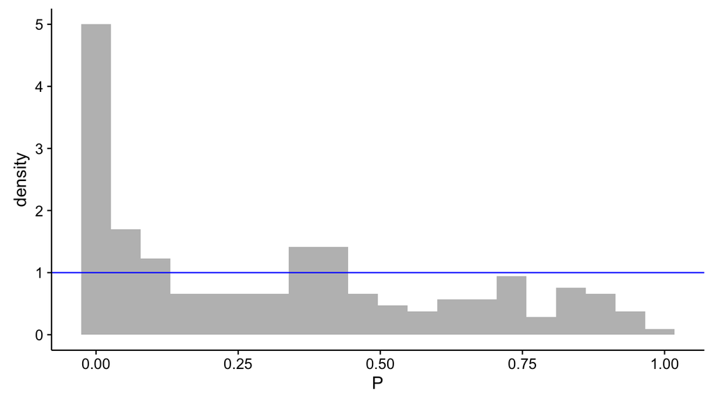

If all H<sub>0</sub> are true, you expect all bars to fall on the blue line.

## Estimation of \(\pi_0\)

- True non-null *P* values will fall nearest 0 (in the first bin: 0 - 0.05).
- Remaining *P* values will be uniformly distributed 0.05 - 1.00.
- Height of the uniform portion of the distribution estimates \(\pi_0\)
  - \(\pi_0\) falls in the range 0 to 1, where 1 equal FDR.
  - Follow the math in Storey & Tibshirani (2003) if you wish

## The \(q\) value

\(q\) is the the minimum FDR that can be attained when calling *that test significant*

- Each *P* value is associated with a \(q\) value
- A *P* value associated with a \(q\) value of 0.05 means that 5% of *P* values lower are expected to be false positives
  - In other words, consider a *P* value with an associated \(q\) value of 0.05. That *P* value and those lower than it should have a false positive rate of 0.05.

## pFDR in practice

- Look at the distribution of your *P* values.
  - The first bin should be largest (you have positive results)
  - If the distribution is completely flat, you can't use pFDR
  - If the distribution looks like a normal curve, is skewed to the right, or has peaks near 0 and 1, then \(\pi_0\) estimation will probably fail. Fall back to FDR or sequential Bonferroni.

## pFDR in practice

- For large numbers of *P* values (hundreds?, thousands?), the default settings in the qvalue package work fine:
  - `lambda = seq(0, 0.90, 0.05)`
  - `pi0.method = "smoother"`
  - This estimates \(\pi_0\) across a sequence of tuning parameters (lambda) using a smoother to determine the optimal \(\pi_0\)
  - If the smoother method fails, try `pi0.method = "bootstrap"` and/or `pdfr = TRUE`

## pFDR in practice

Just pass a vector of *P* values to `qvalue()`:

```r
qobj <- qvalue(Ps$P)
```

Explicitly:

```r
qobj <- qvalue(Ps$P, fdr.level = 0.05, pi0.method = "smoother")
```

## pFDR in practice

```r
summary(qobj)
```

```
##
## Call:
## qvalue(p = Ps$P)
##
## pi0: 0.325085
##
## Cumulative number of significant calls:
##
##           <1e-04 <0.001 <0.01 <0.025 <0.05 <0.1  <1
## p-value       33     37    44     53    62   78 203
## q-value       32     37    42     52    61   84 203
## local FDR     28     32    34     38    40   46 203
```

## Visualizing \(\pi_0 = 0.325\)

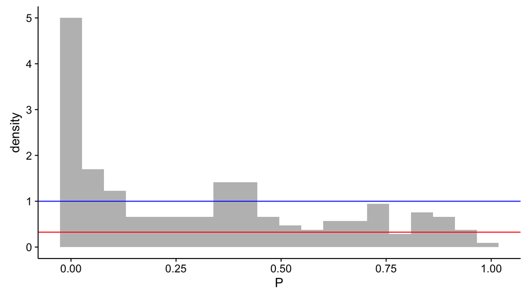

Blue: All H<sub>0</sub> are true. Red: Only 32% of H<sub>0</sub> are true.

## Calculating an adjusted \(\alpha\) level

```r
max(qobj$pvalues[qobj$qvalues <= 0.05])
```

```
## [1] 0.03957791
```

- *Translation*: Find the largest *P* value in `qobj` which has an associated \(q\) value less than or equal to 0.05.
  - So, if you use 0.03957791 as the \(\alpha\) level across all of your *P* values in this example, then you will be controlling the FDR at 0.05.

Include unadjusted *P* values and adjust \(\alpha\). Discuss results with respect to adjusted \(\alpha\).

## Writing about pFDR

> After completing our statistical analyses, a positive false discovery rate (pFDR) analysis was used to control the false discovery rate at 0.05. Our pFDR analysis used the "smoother" option in the R package `qvalue`. We determined that an adjusted \(\alpha\) level of 0.040 controlled experiment-wide false discovery at 5% for our 203 statistical tests, and subsequent inferences (Tables 1-3 in the electronic supplementary materials) use this adjusted \(\alpha\) level. All tables present raw (unadjusted) *P* values.

## Empirical estimate of FDR

How could you estimate the expected number of false positives for a given dataset?

## Quiz 12-3

No more lectures.

## References

Benjamini, Y., and Y. Hochberg. 1995. Controlling the False Discovery Rate: A Practical and Powerful Approach to Multiple Testing. *Journal of the Royal Statistical Society. Series B, Statistical Methodology* 57:289–300.

Storey, J. D. 2002. A Direct Approach to False Discovery Rates. *Journal of the Royal Statistical Society. Series B, Statistical Methodology* 64:479–498.

Storey, J. D., and R. Tibshirani. 2003. Statistical Significance for Genomewide Studies. *Proceedings of the National Academy of Sciences of the United States of America* 100:9440–9445.

Storey, J. D., J. E. Taylor, and D. Siegmund. 2004. Strong Control, Conservative Point Estimation and Simultaneous Conservative Consistency of False Discovery Rates: A Unified Approach. *Journal of the Royal Statistical Society. Series B, Statistical Methodology* 66:187–205.